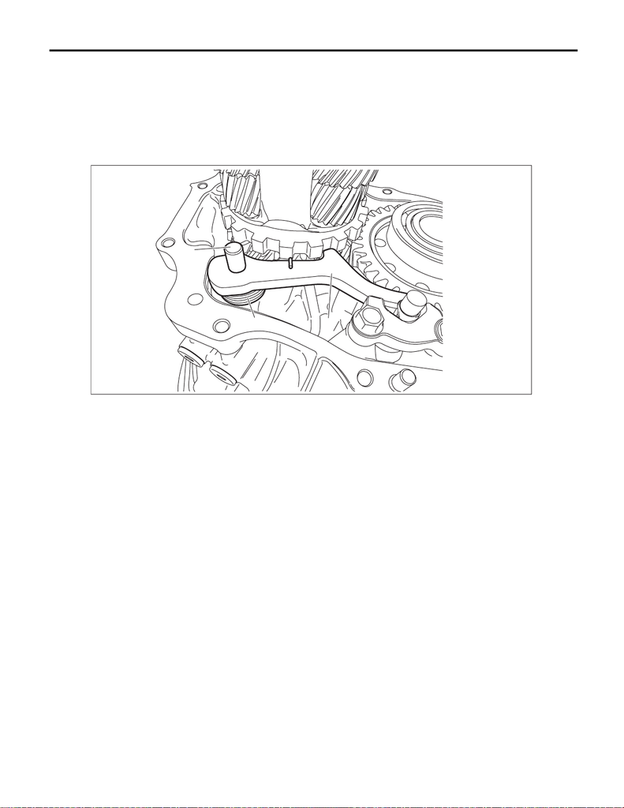

Parking Pawl

CONTINUOUSLY VARIABLE TRANSMISSION

33.Parking Pawl

A: REMOVAL

1) Remove the transmission assembly from the vehicle. <Ref. to CVT(TR690)-56, REMOVAL, Automatic

Transmission Assembly.>

2) Shift the range select lever to “N” range.

3) Remove the extension case. <Ref. to CVT(TR690)-142, REMOVAL, Extension Case.>

4) Remove the parking pawl shaft, return spring and parking pawl.

(A) Parking pawl shaft

(B) Return spring

(C) Parking pawl

AT-07364

(A)

(B) (C)

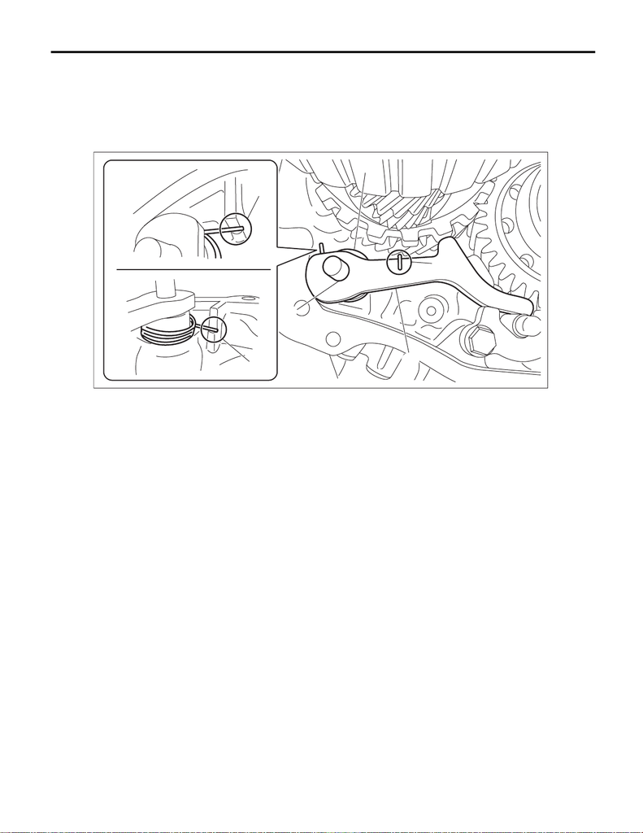

Parking Pawl

CONTINUOUSLY VARIABLE TRANSMISSION

B: INSTALLATION

1) Set the range select lever to the “N” range.

2) Install the parking pawl shaft, return spring and parking pawl.

NOTE:

Make sure that the end of return spring sticks out of parking pawl as shown in (a). Make sure that the other

end contacts the rib of intermediate case as shown in (b).

3) Install the extension case. <Ref. to CVT(TR690)-143, INSTALLATION, Extension Case.>

4) Install the transmission assembly to the vehicle. <Ref. to CVT(TR690)-69, INSTALLATION, Automatic

Transmission Assembly.>

C: INSPECTION

• Check the parking pawl for breakage or damage.

• Check the return spring for fatigue.

(A) Parking pawl shaft

(B) Return spring

(C) Parking pawl

(C)

(A)

(B)

(a)

(b)

(b)

AT-07365